# Open Data Syracuse R Tutorial

R is a language for statistical computing and graphics - it is great for working with data. This tutorial will show how to read in data using the Application Programming Interface (API). It will then show how to make a simple map using `ggplot2`.

This tutorial assumes users have some experience coding. Below are the software requirements for this tutorial:

- An installation of R.
- An Integrated Development Environment (IDE), like RStudio or Positron.
- Alternatively, access to a cloud-based IDE, such as Posit Cloud.

## Packages

```r
library(tidyverse)
library(sf)
```

## Reading Data in from the API

To read in the datasets via the API, we are using the `sf` package to do this since they are spatial datasets, but `jsonlite` is also a great package for reading in JSONs.If preferred, the datasets can also be downloaded manually and the same analysis can be performed.

```r
vacant <- st_read("https://services6.arcgis.com/bdPqSfflsdgFRVVM/arcgis/rest/services/Vacant_Properties/FeatureServer/0/query?outFields=*&where=1%3D1&f=geojson")
```

```
## replacing null geometries with empty geometries
## Simple feature collection with 1514 features and 15 fields (with 1 geometry empty)
## Geometry type: POINT
## Dimension:     XY
## Bounding box:  xmin: -76.20289 ymin: 42.9855 xmax: -76.08296 ymax: 43.08208
## Geodetic CRS:  WGS 84
```

```r
zip <- st_read("https://services6.arcgis.com/bdPqSfflsdgFRVVM/arcgis/rest/services/Syracuse_Zip_Codes_2022_View/FeatureServer/0/query?outFields=*&where=1%3D1&f=geojson")
```

## Grabbing Counts

In the chunk below, `count` is being used to create a dataframe that shows the number of vacant properties per zip code.

`st_drop_geometry` removes the geometry from the the vacant properties data, since the goal is to map the number of vacant properties in each zip code within the City, rather than mapping each individual point.

```r
counts <- count(st_drop_geometry(vacant), Zip)
head(counts)
```

```
##     Zip   n
## 1 13202  20
## 2 13203 200
## 3 13204 303
## 4 13205 491
## 5 13206  76
## 6 13207  82
```

## Joining

Next, the `counts` dataframe is being joined to the zip code polygons.

```r
zips_joined <- left_join(zip, counts, by =(c("ZIP" = "Zip")))
```

## Mapping

The final step is to create a map using `ggplot`.

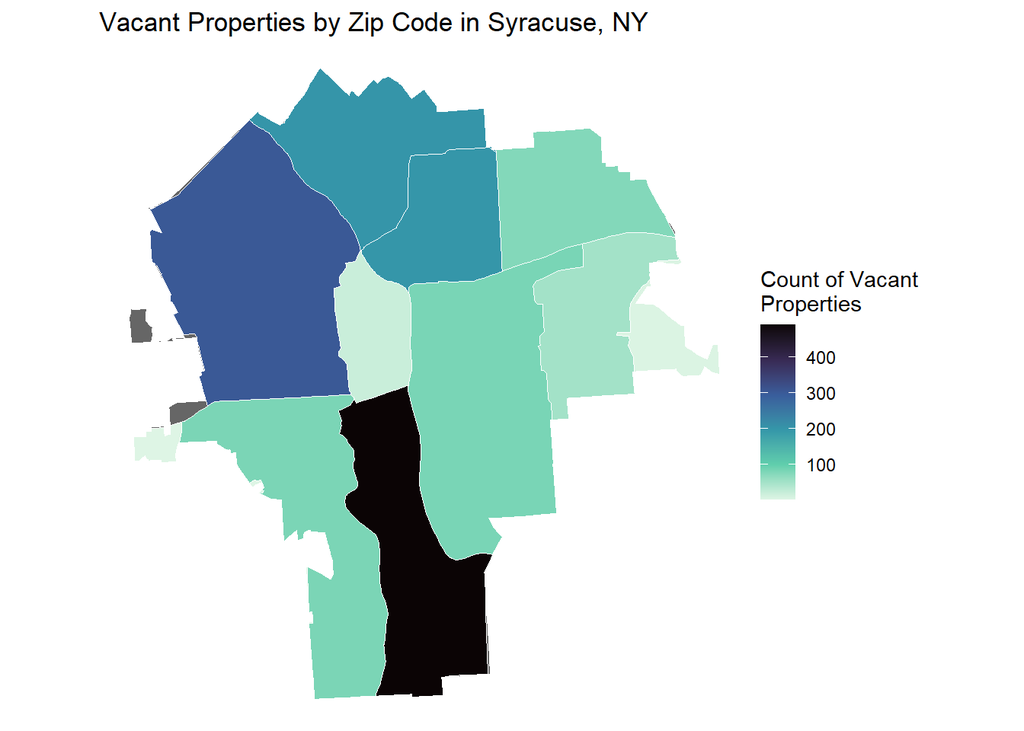

```r
ggplot(zips_joined) +
  geom_sf(aes(fill = n), color = "white") +
  scale_fill_viridis_c(option = "mako", direction = -1, na.value = "grey40") +
  labs(title="Vacant Properties by Zip Code in Syracuse, NY",
       fill = "Count of Vacant \nProperties") +
  theme_void()
```

Thank you for using our tutorial. If you would like to see any other tutorials or datasets on the Syracuse Open Data site, please let us know at opendata@syr.gov!